# Pandemic associated changes in cognition from the CLSA Comprehensive Cohort

### 6.2.2) Estimated marginal means

Significantly lower scores at FU2 for males 65+

```r
lsmeans(modelRVLT_del_adj11, ~Pandemic|timefactor|Age_sex)
```

```
## timefactor = 1, Age_sex = Females 45-64:
##  Pandemic                             lsmean        SE       df  lower.CL
##  FU2 data collected after COVID-19  10.60914 0.1971469 11773.94 10.222696
##  FU2 data collected before COVID-19 10.81460 0.1906861 11314.11 10.440822
##  upper.CL
##  10.99558
##  11.18838
##
## timefactor = 2, Age_sex = Females 45-64:
##  Pandemic                             lsmean        SE       df  lower.CL
##  FU2 data collected after COVID-19  11.42052 0.1975804 11836.41 11.033232
##  FU2 data collected before COVID-19 11.25086 0.1906684 11311.34 10.877116
##  upper.CL
##  11.80781
##  11.62460
##
## timefactor = 1, Age_sex = Females 65+:
##  Pandemic                             lsmean        SE       df  lower.CL
##  FU2 data collected after COVID-19  10.66104 0.2163796 12651.03 10.236902
##  FU2 data collected before COVID-19 11.11081 0.2043714 11957.88 10.710209
##  upper.CL
##  11.08518
##  11.51141
##
## timefactor = 2, Age_sex = Females 65+:
##  Pandemic                             lsmean        SE       df  lower.CL
##  FU2 data collected after COVID-19  10.80169 0.2187777 12960.17 10.372849
##  FU2 data collected before COVID-19 11.03647 0.2044319 11966.28 10.635748
##  upper.CL
##  11.23052
##  11.43719
##
## timefactor = 1, Age_sex = Males 45-64:
##  Pandemic                             lsmean        SE       df  lower.CL
##  FU2 data collected after COVID-19  10.12180 0.1894798 11433.08  9.750385
##  FU2 data collected before COVID-19 10.32862 0.1974057 11795.92  9.941674
##  upper.CL
##  10.49321
##  10.71557
##
```

[output cut: 12 more lines]

```
##  upper.CL
##  10.61423
##  10.78678
##
## timefactor = 2, Age_sex = Males 65+:
##  Pandemic                             lsmean        SE       df  lower.CL
##  FU2 data collected after COVID-19  10.19650 0.2184803 12795.20  9.768243
##  FU2 data collected before COVID-19 10.58112 0.2040985 12053.06 10.181052
##  upper.CL
##  10.62475
##  10.98118
##
## Results are averaged over the levels of: Education, Ethnicity, IncomeLevel, SmokingStatus, Relationshipstatus, Livingstatus, Anxiety, MoodDisord
## Degrees-of-freedom method: kenward-roger
## Confidence level used: 0.95
```

```r
contrast(lsmeans(modelRVLT_del_adj11, ~Pandemic|timefactor|Age_sex), "pairwise", adj="none")
```

```
## timefactor = 1, Age_sex = Females 45-64:
##  contrast
##  (FU2 data collected after COVID-19) - (FU2 data collected before COVID-19)
##    estimate        SE       df t.ratio p.value
##  -0.2054627 0.1173793 17734.40  -1.750  0.0801
##
## timefactor = 2, Age_sex = Females 45-64:
##  contrast
##  (FU2 data collected after COVID-19) - (FU2 data collected before COVID-19)
##    estimate        SE       df t.ratio p.value
##   0.1696624 0.1185313 17894.94   1.431  0.1523
##
## timefactor = 1, Age_sex = Females 65+:
##  contrast
##  (FU2 data collected after COVID-19) - (FU2 data collected before COVID-19)
##    estimate        SE       df t.ratio p.value
##  -0.4497714 0.1611727 17744.06  -2.791  0.0053
##
## timefactor = 2, Age_sex = Females 65+:
##  contrast
##  (FU2 data collected after COVID-19) - (FU2 data collected before COVID-19)
##    estimate        SE       df t.ratio p.value
##  -0.2347825 0.1641374 18037.41  -1.430  0.1526
##
## timefactor = 1, Age_sex = Males 45-64:
##  contrast
##  (FU2 data collected after COVID-19) - (FU2 data collected before COVID-19)
##    estimate        SE       df t.ratio p.value
##  -0.2068246 0.1202199 17793.45  -1.720  0.0854
##
## timefactor = 2, Age_sex = Males 45-64:
##  contrast
##  (FU2 data collected after COVID-19) - (FU2 data collected before COVID-19)
##    estimate        SE       df t.ratio p.value
##   0.1951070 0.1203034 17804.95   1.622  0.1049
##
## timefactor = 1, Age_sex = Males 65+:
##  contrast
##  (FU2 data collected after COVID-19) - (FU2 data collected before COVID-19)
##    estimate        SE       df t.ratio p.value
##  -0.1967185 0.1609259 17895.46  -1.222  0.2216
##
## timefactor = 2, Age_sex = Males 65+:
##  contrast
##  (FU2 data collected after COVID-19) - (FU2 data collected before COVID-19)
##    estimate        SE       df t.ratio p.value
##  -0.3846216 0.1624764 18046.87  -2.367  0.0179
##
## Results are averaged over the levels of: Education, Ethnicity, IncomeLevel, SmokingStatus, Relationshipstatus, Livingstatus, Anxiety, MoodDisord
## Degrees-of-freedom method: kenward-roger
```

```r
confint(contrast(lsmeans(modelRVLT_del_adj11, ~Pandemic|timefactor|Age_sex), "pairwise", adj="none"), parm, level = 0.95)
```

```
## timefactor = 1, Age_sex = Females 45-64:
##  contrast
##  (FU2 data collected after COVID-19) - (FU2 data collected before COVID-19)
##    estimate        SE       df   lower.CL   upper.CL
##  -0.2054627 0.1173793 17734.40 -0.4355376  0.0246121
##
## timefactor = 2, Age_sex = Females 45-64:
##  contrast
##  (FU2 data collected after COVID-19) - (FU2 data collected before COVID-19)
##    estimate        SE       df   lower.CL   upper.CL
##   0.1696624 0.1185313 17894.94 -0.0626705  0.4019953
##
## timefactor = 1, Age_sex = Females 65+:
##  contrast
##  (FU2 data collected after COVID-19) - (FU2 data collected before COVID-19)
##    estimate        SE       df   lower.CL   upper.CL
##  -0.4497714 0.1611727 17744.06 -0.7656856 -0.1338571
##
## timefactor = 2, Age_sex = Females 65+:
##  contrast
##  (FU2 data collected after COVID-19) - (FU2 data collected before COVID-19)
##    estimate        SE       df   lower.CL   upper.CL
##  -0.2347825 0.1641374 18037.41 -0.5565075  0.0869426
##
## timefactor = 1, Age_sex = Males 45-64:
##  contrast
##  (FU2 data collected after COVID-19) - (FU2 data collected before COVID-19)
##    estimate        SE       df   lower.CL   upper.CL
##  -0.2068246 0.1202199 17793.45 -0.4424674  0.0288181
##
## timefactor = 2, Age_sex = Males 45-64:
##  contrast
##  (FU2 data collected after COVID-19) - (FU2 data collected before COVID-19)
##    estimate        SE       df   lower.CL   upper.CL
##   0.1951070 0.1203034 17804.95 -0.0406994  0.4309133
##
## timefactor = 1, Age_sex = Males 65+:
##  contrast
##  (FU2 data collected after COVID-19) - (FU2 data collected before COVID-19)
##    estimate        SE       df   lower.CL   upper.CL
##  -0.1967185 0.1609259 17895.46 -0.5121488  0.1187117
##
## timefactor = 2, Age_sex = Males 65+:
##  contrast
##  (FU2 data collected after COVID-19) - (FU2 data collected before COVID-19)
##    estimate        SE       df   lower.CL   upper.CL
##  -0.3846216 0.1624764 18046.87 -0.7030909 -0.0661523
##
## Results are averaged over the levels of: Education, Ethnicity, IncomeLevel, SmokingStatus, Relationshipstatus, Livingstatus, Anxiety, MoodDisord
## Degrees-of-freedom method: kenward-roger
## Confidence level used: 0.95
```

### 6.2.3) Graph of estimated marginal means

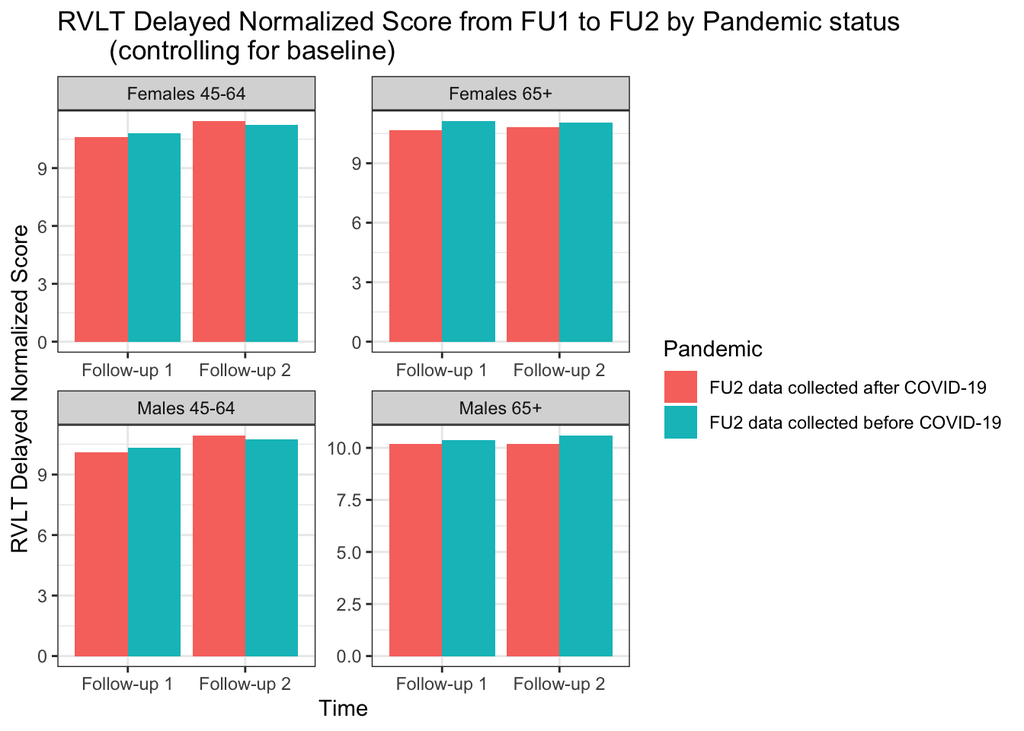

```r
RVLTdelayed_lsmeans_adj11 <- summary(lsmeans(modelRVLT_del_adj11, ~timefactor|Pandemic|Age_sex))
RVLTdelayed_lsmeans_adj11$Time<-NA
RVLTdelayed_lsmeans_adj11$Time[RVLTdelayed_lsmeans_adj11$timefactor==1]<-"Follow-up 1"
RVLTdelayed_lsmeans_adj11$Time[RVLTdelayed_lsmeans_adj11$timefactor==2]<-"Follow-up 2"
ggplot(RVLTdelayed_lsmeans_adj11, aes(x = Time, y = lsmean, fill = Pandemic)) +
  geom_bar(stat="identity", position=position_dodge()) + facet_wrap(~Age_sex, scales = "free") +
  labs(x = "Time", y = "RVLT Delayed Normalized Score", title = "RVLT Delayed Normalized Score from FU1 to FU2 by Pandemic status
       (controlling for baseline)") +
  theme_bw()
```

### 6.2.4) Post-hoc comparisons

There was a significant difference between cohorts for males 65+. This post-hoc comparison determines if differences between cohorts at FU1 and FU2 for 65+ males are significant.

```r
lsmeans.RVLT_del <- lsmeans(modelRVLT_del_adj11, ~Pandemic|timefactor|Age_sex)
contrast.RVLT_del<-contrast(lsmeans.RVLT_del,list(c2nd),by=NULL)
contrast.RVLT_del_95<-confint(contrast.RVLT_del, parm, level = 0.95)
print(contrast.RVLT_del)
```

```
##  contrast
##  structure(c(0, 0, 0, 0, 0, 0, 0, 0, 0, 0, 0, 0, 1, -1, -1, 1), dim = c(16L,
##   estimate        SE       df t.ratio p.value
##  0.1879031 0.1832561 10183.52   1.025  0.3052
##
## Results are averaged over the levels of: Education, Ethnicity, IncomeLevel, SmokingStatus, Relationshipstatus, Livingstatus, Anxiety, MoodDisord
## Degrees-of-freedom method: kenward-roger
```

```r
print(contrast.RVLT_del_95)
```

```
##  contrast
##  structure(c(0, 0, 0, 0, 0, 0, 0, 0, 0, 0, 0, 0, 1, -1, -1, 1), dim = c(16L,
##   estimate        SE       df   lower.CL  upper.CL
##  0.1879031 0.1832561 10183.52 -0.1713149 0.5471211
##
## Results are averaged over the levels of: Education, Ethnicity, IncomeLevel, SmokingStatus, Relationshipstatus, Livingstatus, Anxiety, MoodDisord
## Degrees-of-freedom method: kenward-roger
## Confidence level used: 0.95
```

Effect size from post-hoc

```r
df.contrast.RVLT_del<-as.data.frame(contrast.RVLT_del)
n_males_65<-nrow(subset(Tracking.Adjusted_Final, Age_sex == "Males 65+" & Pandemic == "FU2 data collected after COVID-19"))
es_RVLT_del<-(df.contrast.RVLT_del$t.ratio*2)/(sqrt(n_males_65 + n_males_65))
print(es_RVLT_del)
```

```
## [1] 0.05051576
```

## 6.3) Mental Alteration Test

### 6.3.1) Model

```r
modelMAT_adj11<- lmer(MAT_Normed~ timefactor*Pandemic*Age_sex + Education + Ethnicity + IncomeLevel + BMI + CESD.10baseline + SmokingStatus + Relationshipstatus +
                            Livingstatus + Anxiety + MoodDisord + Chronicconditions + MAT_Normedbaseline +
                      (1|ID), data= Tracking.data_long_2)
summary(modelMAT_adj11)
```

```
## Linear mixed model fit by REML. t-tests use Satterthwaite's method [
## lmerModLmerTest]
## Formula:
## MAT_Normed ~ timefactor * Pandemic * Age_sex + Education + Ethnicity +
##     IncomeLevel + BMI + CESD.10baseline + SmokingStatus + Relationshipstatus +
##     Livingstatus + Anxiety + MoodDisord + Chronicconditions +
##     MAT_Normedbaseline + (1 | ID)
##    Data: Tracking.data_long_2
##
## REML criterion at convergence: 97258.2
##
## Scaled residuals:
##     Min      1Q  Median      3Q     Max
## -3.4157 -0.5134 -0.0505  0.3918  4.6109
##
## Random effects:
##  Groups   Name        Variance Std.Dev.
##  ID       (Intercept) 2.617    1.618
##  Residual             7.857    2.803
## Number of obs: 18841, groups:  ID, 10262
##
## Fixed effects:
##                                                                             Estimate
## (Intercept)                                                                8.506e+00
## timefactor2                                                               -3.390e+00
## PandemicFU2 data collected before COVID-19                                -1.609e+00
## Age_sexFemales 65+                                                        -9.236e-01
## Age_sexMales 45-64                                                        -3.457e+00
## Age_sexMales 65+                                                          -3.492e+00
## EducationHigh School Diploma                                              -1.927e-02
## EducationLess than High School Diploma                                    -1.655e-01
## EducationSome College                                                     -1.753e-01
## EthnicityWhite                                                             8.811e-01
## IncomeLevel>$150k                                                          1.679e-01
## IncomeLevel$100-150k                                                       1.954e-01
## IncomeLevel$20-50k                                                         9.886e-02
## IncomeLevel$50-100k                                                        1.481e-01
## BMI                                                                       -1.358e-02
## CESD.10baseline                                                           -1.386e-02
## SmokingStatusFormer Smoker                                                 4.959e-02
```

[output cut: 215 more lines]

```
## MoodDisordYes
## Chronicconditions                                                         **
## MAT_Normedbaseline                                                        ***
## timefactor2:PandemicFU2 data collected before COVID-19                    ***
## timefactor2:Age_sexFemales 65+                                            ***
## timefactor2:Age_sexMales 45-64                                            ***
## timefactor2:Age_sexMales 65+                                              ***
## PandemicFU2 data collected before COVID-19:Age_sexFemales 65+
## PandemicFU2 data collected before COVID-19:Age_sexMales 45-64             ***
## PandemicFU2 data collected before COVID-19:Age_sexMales 65+               ***
## timefactor2:PandemicFU2 data collected before COVID-19:Age_sexFemales 65+
## timefactor2:PandemicFU2 data collected before COVID-19:Age_sexMales 45-64 ***
## timefactor2:PandemicFU2 data collected before COVID-19:Age_sexMales 65+   ***
## ---
## Signif. codes:  0 '***' 0.001 '**' 0.01 '*' 0.05 '.' 0.1 ' ' 1
```

```
##
## Correlation matrix not shown by default, as p = 40 > 12.
## Use print(x, correlation=TRUE)  or
##     vcov(x)        if you need it
```

```r
anova(modelMAT_adj11)
```

```
## Type III Analysis of Variance Table with Satterthwaite's method
##                              Sum Sq Mean Sq NumDF   DenDF   F value    Pr(>F)
## timefactor                   5230.1  5230.1     1  9817.9  665.6614 < 2.2e-16
## Pandemic                      117.9   117.9     1 10185.2   15.0061 0.0001078
## Age_sex                      3898.4  1299.5     3 10141.0  165.3911 < 2.2e-16
## Education                      35.9    12.0     3 10043.7    1.5248 0.2058103
## Ethnicity                     232.1   232.1     1 10164.4   29.5375 5.611e-08
## IncomeLevel                    28.6     7.2     4  9964.1    0.9105 0.4566491
## BMI                            51.7    51.7     1  9851.2    6.5829 0.0103112
## CESD.10baseline                35.8    35.8     1  9960.1    4.5517 0.0329111
## SmokingStatus                  26.7     8.9     3  9942.4    1.1345 0.3335396
## Relationshipstatus            200.0    50.0     4 10062.3    6.3652 4.120e-05
## Livingstatus                   79.9    26.6     3 10044.7    3.3909 0.0171896
## Anxiety                        11.2    11.2     1  9993.4    1.4191 0.2335774
## MoodDisord                      0.1     0.1     1  9930.9    0.0080 0.9288023
## Chronicconditions              84.7    84.7     1 10095.4   10.7777 0.0010308
## MAT_Normedbaseline          25849.9 25849.9     1 10062.7 3290.0323 < 2.2e-16
## timefactor:Pandemic           716.3   716.3     1  9818.4   91.1717 < 2.2e-16
## timefactor:Age_sex           5550.9  1850.3     3  9759.5  235.4981 < 2.2e-16
## Pandemic:Age_sex              458.7   152.9     3 10146.3   19.4623 1.409e-12
## timefactor:Pandemic:Age_sex   893.1   297.7     3  9759.5   37.8895 < 2.2e-16
##
## timefactor                  ***
## Pandemic                    ***
## Age_sex                     ***
## Education
## Ethnicity                   ***
## IncomeLevel
## BMI                         *
## CESD.10baseline             *
## SmokingStatus
## Relationshipstatus          ***
## Livingstatus                *
## Anxiety
## MoodDisord
## Chronicconditions           **
## MAT_Normedbaseline          ***
## timefactor:Pandemic         ***
## timefactor:Age_sex          ***
## Pandemic:Age_sex            ***
## timefactor:Pandemic:Age_sex ***
## ---
## Signif. codes:  0 '***' 0.001 '**' 0.01 '*' 0.05 '.' 0.1 ' ' 1
```

### 6.3.2) Estimated marginal means

```r
lsmeans(modelMAT_adj11, ~Pandemic|timefactor|Age_sex)
```

```
## timefactor = 1, Age_sex = Females 45-64:
##  Pandemic                              lsmean        SE       df  lower.CL
##  FU2 data collected after COVID-19  12.696519 0.1905041 11855.95 12.323099
##  FU2 data collected before COVID-19 11.087143 0.1837216 11296.31 10.727017
##   upper.CL
##  13.069938
##  11.447269
##
## timefactor = 2, Age_sex = Females 45-64:
##  Pandemic                              lsmean        SE       df  lower.CL
##  FU2 data collected after COVID-19   9.306276 0.1907101 11881.60  8.932453
##  FU2 data collected before COVID-19  9.427605 0.1834602 11260.94  9.067991
##   upper.CL
##   9.680099
##   9.787219
##
## timefactor = 1, Age_sex = Females 65+:
##  Pandemic                              lsmean        SE       df  lower.CL
##  FU2 data collected after COVID-19  11.772876 0.2121837 13142.93 11.356965
##  FU2 data collected before COVID-19 10.419276 0.1976457 12091.40 10.031859
##   upper.CL
##  12.188787
##  10.806694
##
## timefactor = 2, Age_sex = Females 65+:
##  Pandemic                              lsmean        SE       df  lower.CL
##  FU2 data collected after COVID-19   9.093475 0.2130980 13240.43  8.675772
##  FU2 data collected before COVID-19  9.520122 0.1978095 12111.32  9.132383
##   upper.CL
##   9.511177
##   9.907860
##
## timefactor = 1, Age_sex = Males 45-64:
##  Pandemic                              lsmean        SE       df  lower.CL
##  FU2 data collected after COVID-19   9.239715 0.1827928 11440.94  8.881410
##  FU2 data collected before COVID-19  9.317922 0.1910888 11929.91  8.943357
##   upper.CL
##   9.598020
##   9.692487
##
```

[output cut: 12 more lines]

```
##   upper.CL
##   9.621768
##   9.891095
##
## timefactor = 2, Age_sex = Males 65+:
##  Pandemic                              lsmean        SE       df  lower.CL
##  FU2 data collected after COVID-19   8.890290 0.2151540 13226.18  8.468558
##  FU2 data collected before COVID-19  9.173133 0.1986219 12298.67  8.783803
##   upper.CL
##   9.312023
##   9.562463
##
## Results are averaged over the levels of: Education, Ethnicity, IncomeLevel, SmokingStatus, Relationshipstatus, Livingstatus, Anxiety, MoodDisord
## Degrees-of-freedom method: kenward-roger
## Confidence level used: 0.95
```

```r
contrast(lsmeans(modelMAT_adj11, ~Pandemic|timefactor|Age_sex), "pairwise", adj="none")
```

```
## timefactor = 1, Age_sex = Females 45-64:
##  contrast
##  (FU2 data collected after COVID-19) - (FU2 data collected before COVID-19)
##    estimate        SE       df t.ratio p.value
##   1.6093755 0.1170264 17996.69  13.752  <.0001
##
## timefactor = 2, Age_sex = Females 45-64:
##  contrast
##  (FU2 data collected after COVID-19) - (FU2 data collected before COVID-19)
##    estimate        SE       df t.ratio p.value
##  -0.1213285 0.1175053 18025.46  -1.033  0.3018
##
## timefactor = 1, Age_sex = Females 65+:
##  contrast
##  (FU2 data collected after COVID-19) - (FU2 data collected before COVID-19)
##    estimate        SE       df t.ratio p.value
##   1.3535998 0.1641553 18093.83   8.246  <.0001
##
## timefactor = 2, Age_sex = Females 65+:
##  contrast
##  (FU2 data collected after COVID-19) - (FU2 data collected before COVID-19)
##    estimate        SE       df t.ratio p.value
##  -0.4266467 0.1663959 18178.31  -2.564  0.0104
##
## timefactor = 1, Age_sex = Males 45-64:
##  contrast
##  (FU2 data collected after COVID-19) - (FU2 data collected before COVID-19)
##    estimate        SE       df t.ratio p.value
##  -0.0782070 0.1203861 18053.11  -0.650  0.5159
##
## timefactor = 2, Age_sex = Males 45-64:
##  contrast
##  (FU2 data collected after COVID-19) - (FU2 data collected before COVID-19)
##    estimate        SE       df t.ratio p.value
##  -0.0015620 0.1199586 18028.66  -0.013  0.9896
##
## timefactor = 1, Age_sex = Males 65+:
##  contrast
##  (FU2 data collected after COVID-19) - (FU2 data collected before COVID-19)
##    estimate        SE       df t.ratio p.value
##  -0.2980262 0.1641423 18122.43  -1.816  0.0694
##
## timefactor = 2, Age_sex = Males 65+:
##  contrast
##  (FU2 data collected after COVID-19) - (FU2 data collected before COVID-19)
##    estimate        SE       df t.ratio p.value
##  -0.2828423 0.1675609 18244.13  -1.688  0.0914
##
## Results are averaged over the levels of: Education, Ethnicity, IncomeLevel, SmokingStatus, Relationshipstatus, Livingstatus, Anxiety, MoodDisord
## Degrees-of-freedom method: kenward-roger
```

```r
confint(contrast(lsmeans(modelMAT_adj11, ~Pandemic|timefactor|Age_sex), "pairwise", adj="none"), parm, level = 0.95)
```

```
## timefactor = 1, Age_sex = Females 45-64:
##  contrast
##  (FU2 data collected after COVID-19) - (FU2 data collected before COVID-19)
##    estimate        SE       df   lower.CL   upper.CL
##   1.6093755 0.1170264 17996.69  1.3799926  1.8387584
##
## timefactor = 2, Age_sex = Females 45-64:
##  contrast
##  (FU2 data collected after COVID-19) - (FU2 data collected before COVID-19)
##    estimate        SE       df   lower.CL   upper.CL
##  -0.1213285 0.1175053 18025.46 -0.3516502  0.1089931
##
## timefactor = 1, Age_sex = Females 65+:
##  contrast
##  (FU2 data collected after COVID-19) - (FU2 data collected before COVID-19)
##    estimate        SE       df   lower.CL   upper.CL
##   1.3535998 0.1641553 18093.83  1.0318397  1.6753598
##
## timefactor = 2, Age_sex = Females 65+:
##  contrast
##  (FU2 data collected after COVID-19) - (FU2 data collected before COVID-19)
##    estimate        SE       df   lower.CL   upper.CL
##  -0.4266467 0.1663959 18178.31 -0.7527985 -0.1004949
##
## timefactor = 1, Age_sex = Males 45-64:
##  contrast
##  (FU2 data collected after COVID-19) - (FU2 data collected before COVID-19)
##    estimate        SE       df   lower.CL   upper.CL
##  -0.0782070 0.1203861 18053.11 -0.3141752  0.1577612
##
## timefactor = 2, Age_sex = Males 45-64:
##  contrast
##  (FU2 data collected after COVID-19) - (FU2 data collected before COVID-19)
##    estimate        SE       df   lower.CL   upper.CL
##  -0.0015620 0.1199586 18028.66 -0.2366923  0.2335683
##
## timefactor = 1, Age_sex = Males 65+:
##  contrast
##  (FU2 data collected after COVID-19) - (FU2 data collected before COVID-19)
##    estimate        SE       df   lower.CL   upper.CL
##  -0.2980262 0.1641423 18122.43 -0.6197607  0.0237083
##
## timefactor = 2, Age_sex = Males 65+:
##  contrast
##  (FU2 data collected after COVID-19) - (FU2 data collected before COVID-19)
##    estimate        SE       df   lower.CL   upper.CL
##  -0.2828423 0.1675609 18244.13 -0.6112773  0.0455928
##
## Results are averaged over the levels of: Education, Ethnicity, IncomeLevel, SmokingStatus, Relationshipstatus, Livingstatus, Anxiety, MoodDisord
## Degrees-of-freedom method: kenward-roger
## Confidence level used: 0.95
```

### 6.3.3) Graph of estimated marginal means

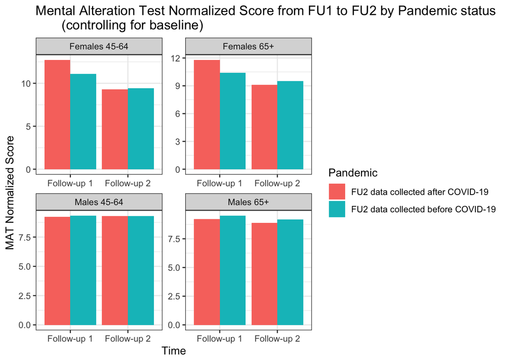

```r
MAT_lsmeans_adj11 <- summary(lsmeans(modelMAT_adj11, ~Pandemic|timefactor|Age_sex))
MAT_lsmeans_adj11$Time<-NA
MAT_lsmeans_adj11$Time[MAT_lsmeans_adj11$timefactor==1]<-"Follow-up 1"
MAT_lsmeans_adj11$Time[MAT_lsmeans_adj11$timefactor==2]<-"Follow-up 2"
ggplot(MAT_lsmeans_adj11, aes(x = Time, y = lsmean, fill = Pandemic)) +
  geom_bar(stat="identity", position=position_dodge()) + facet_wrap(~Age_sex, scales = "free") +
  labs(x = "Time", y = "MAT Normalized Score", title = "Mental Alteration Test Normalized Score from FU1 to FU2 by Pandemic status
       (controlling for baseline)") +
  theme_bw()
```

### 6.3.4) Post-hoc comparisons

There was a significant difference between cohorts for females 65+. This post-hoc comparison determines if differences between cohorts at FU1 and FU2 for 65+ females are significant.

```r
lsmeans.MAT <- lsmeans(modelMAT_adj11, ~Pandemic|timefactor|Age_sex)
contrast.MAT<-contrast(lsmeans.MAT,list(c3rd),by=NULL)
contrast.MAT_95<-confint(contrast.MAT, parm, level = 0.95)
print(contrast.MAT)
```

```
##  contrast
##  structure(c(0, 0, 0, 0, 1, -1, -1, 1, 0, 0, 0, 0, 0, 0, 0, 0), dim = c(16L,
##  estimate        SE      df t.ratio p.value
##  1.780247 0.2054848 9979.28   8.664  <.0001
##
## Results are averaged over the levels of: Education, Ethnicity, IncomeLevel, SmokingStatus, Relationshipstatus, Livingstatus, Anxiety, MoodDisord
## Degrees-of-freedom method: kenward-roger
```

```r
print(contrast.MAT_95)
```

```
##  contrast
##  structure(c(0, 0, 0, 0, 1, -1, -1, 1, 0, 0, 0, 0, 0, 0, 0, 0), dim = c(16L,
##  estimate        SE      df lower.CL upper.CL
##  1.780247 0.2054848 9979.28 1.377455 2.183038
##
## Results are averaged over the levels of: Education, Ethnicity, IncomeLevel, SmokingStatus, Relationshipstatus, Livingstatus, Anxiety, MoodDisord
## Degrees-of-freedom method: kenward-roger
## Confidence level used: 0.95
```

Effect size from post-hoc

```r
df.contrast.MAT<-as.data.frame(contrast.MAT)
n_females_65<-nrow(subset(Tracking.Adjusted_Final, Age_sex == "Females 65+" & Pandemic == "FU2 data collected after COVID-19"))
es_MAT<-(df.contrast.MAT$t.ratio*2)/(sqrt(n_females_65 + n_females_65))
print(es_MAT)
```

```
## [1] 0.4260521
```

## 6.4) Animal Fluency

### 6.4.1) Model

```r
modelAnimals_adj11<- lmer(Animal_Fluency_Normed ~ timefactor*Pandemic*Age_sex + Education + Ethnicity + IncomeLevel + BMI + CESD.10baseline + SmokingStatus + Relationshipstatus +
                            Livingstatus + Anxiety + MoodDisord + Chronicconditions + Animal_Fluency_Normedbaseline +
                           (1|ID), data= Tracking.data_long_2)
summary(modelAnimals_adj11)
```

```
## Linear mixed model fit by REML. t-tests use Satterthwaite's method [
## lmerModLmerTest]
## Formula: Animal_Fluency_Normed ~ timefactor * Pandemic * Age_sex + Education +
##     Ethnicity + IncomeLevel + BMI + CESD.10baseline + SmokingStatus +
##     Relationshipstatus + Livingstatus + Anxiety + MoodDisord +
##     Chronicconditions + Animal_Fluency_Normedbaseline + (1 |      ID)
##    Data: Tracking.data_long_2
##
## REML criterion at convergence: 94883.1
##
## Scaled residuals:
##     Min      1Q  Median      3Q     Max
## -3.9084 -0.5456 -0.0177  0.5260  4.5905
##
## Random effects:
##  Groups   Name        Variance Std.Dev.
##  ID       (Intercept) 3.012    1.735
##  Residual             3.861    1.965
## Number of obs: 20333, groups:  ID, 10403
##
## Fixed effects:
##                                                                             Estimate
## (Intercept)                                                                4.188e+00
## timefactor2                                                                2.776e-01
## PandemicFU2 data collected before COVID-19                                 2.798e-01
## Age_sexFemales 65+                                                        -3.304e-01
## Age_sexMales 45-64                                                         6.509e-02
## Age_sexMales 65+                                                          -2.951e-01
## EducationHigh School Diploma                                               2.178e-01
## EducationLess than High School Diploma                                     5.810e-02
## EducationSome College                                                      2.113e-01
## EthnicityWhite                                                             5.876e-01
## IncomeLevel>$150k                                                          1.545e-01
## IncomeLevel$100-150k                                                       2.370e-01
## IncomeLevel$20-50k                                                        -1.204e-02
## IncomeLevel$50-100k                                                        1.912e-01
## BMI                                                                       -3.383e-03
## CESD.10baseline                                                           -1.300e-02
## SmokingStatusFormer Smoker                                                 7.776e-02
## SmokingStatusNever Smoked                                                  7.149e-02
```

[output cut: 214 more lines]

```
## MoodDisordYes
## Chronicconditions                                                         **
## Animal_Fluency_Normedbaseline                                             ***
## timefactor2:PandemicFU2 data collected before COVID-19
## timefactor2:Age_sexFemales 65+                                            **
## timefactor2:Age_sexMales 45-64                                            *
## timefactor2:Age_sexMales 65+                                              ***
## PandemicFU2 data collected before COVID-19:Age_sexFemales 65+
## PandemicFU2 data collected before COVID-19:Age_sexMales 45-64             *
## PandemicFU2 data collected before COVID-19:Age_sexMales 65+
## timefactor2:PandemicFU2 data collected before COVID-19:Age_sexFemales 65+
## timefactor2:PandemicFU2 data collected before COVID-19:Age_sexMales 45-64
## timefactor2:PandemicFU2 data collected before COVID-19:Age_sexMales 65+   *
## ---
## Signif. codes:  0 '***' 0.001 '**' 0.01 '*' 0.05 '.' 0.1 ' ' 1
```

```
##
## Correlation matrix not shown by default, as p = 40 > 12.
## Use print(x, correlation=TRUE)  or
##     vcov(x)        if you need it
```

```r
anova(modelAnimals_adj11)
```

```
## Type III Analysis of Variance Table with Satterthwaite's method
##                                Sum Sq Mean Sq NumDF DenDF   F value    Pr(>F)
## timefactor                        1.1     1.1     1 10161    0.2802  0.596560
## Pandemic                         68.2    68.2     1 10346   17.6669 2.654e-05
## Age_sex                         290.6    96.9     3 10344   25.0872 3.636e-16
## Education                        54.6    18.2     3 10347    4.7164  0.002721
## Ethnicity                        72.6    72.6     1 10290   18.8151 1.454e-05
## IncomeLevel                      70.0    17.5     4 10315    4.5353  0.001166
## BMI                               2.2     2.2     1 10274    0.5744  0.448517
## CESD.10baseline                  21.8    21.8     1 10351    5.6510  0.017464
## SmokingStatus                     5.0     1.7     3 10318    0.4349  0.727998
## Relationshipstatus               20.7     5.2     4 10346    1.3374  0.253362
## Livingstatus                     43.2    14.4     3 10265    3.7272  0.010811
## Anxiety                           1.6     1.6     1 10334    0.4145  0.519710
## MoodDisord                        7.3     7.3     1 10337    1.8862  0.169660
## Chronicconditions                27.6    27.6     1 10306    7.1372  0.007562
## Animal_Fluency_Normedbaseline 28580.1 28580.1     1 10308 7402.2611 < 2.2e-16
## timefactor:Pandemic               1.5     1.5     1 10161    0.3813  0.536933
## timefactor:Age_sex              107.6    35.9     3 10158    9.2928 3.921e-06
## Pandemic:Age_sex                 32.7    10.9     3 10346    2.8232  0.037292
## timefactor:Pandemic:Age_sex      21.1     7.0     3 10158    1.8212  0.140912
##
## timefactor
## Pandemic                      ***
## Age_sex                       ***
## Education                     **
## Ethnicity                     ***
## IncomeLevel                   **
## BMI
## CESD.10baseline               *
## SmokingStatus
## Relationshipstatus
## Livingstatus                  *
## Anxiety
## MoodDisord
## Chronicconditions             **
## Animal_Fluency_Normedbaseline ***
## timefactor:Pandemic
## timefactor:Age_sex            ***
## Pandemic:Age_sex              *
## timefactor:Pandemic:Age_sex
## ---
## Signif. codes:  0 '***' 0.001 '**' 0.01 '*' 0.05 '.' 0.1 ' ' 1
```

### 6.4.2) Estimated marginal means

Significantly lower animal fluency for males and females 65+

```r
lsmeans(modelAnimals_adj11, ~Pandemic|timefactor|Age_sex)
```

```
## timefactor = 1, Age_sex = Females 45-64:
##  Pandemic                             lsmean        SE       df lower.CL
##  FU2 data collected after COVID-19  10.94182 0.1571540 11565.78 10.63377
##  FU2 data collected before COVID-19 11.22163 0.1522728 11167.93 10.92315
##  upper.CL
##  11.24987
##  11.52011
##
## timefactor = 2, Age_sex = Females 45-64:
##  Pandemic                             lsmean        SE       df lower.CL
##  FU2 data collected after COVID-19  11.21946 0.1575160 11635.47 10.91070
##  FU2 data collected before COVID-19 11.38502 0.1522720 11167.75 11.08654
##  upper.CL
##  11.52822
##  11.68350
##
## timefactor = 1, Age_sex = Females 65+:
##  Pandemic                             lsmean        SE       df lower.CL
##  FU2 data collected after COVID-19  10.61142 0.1720851 12338.96 10.27410
##  FU2 data collected before COVID-19 10.95718 0.1625537 11691.72 10.63855
##  upper.CL
##  10.94873
##  11.27581
##
## timefactor = 2, Age_sex = Females 65+:
##  Pandemic                             lsmean        SE       df lower.CL
##  FU2 data collected after COVID-19  10.50797 0.1731142 12518.78 10.16864
##  FU2 data collected before COVID-19 10.78501 0.1627453 11727.44 10.46600
##  upper.CL
##  10.84730
##  11.10402
##
## timefactor = 1, Age_sex = Males 45-64:
##  Pandemic                             lsmean        SE       df lower.CL
##  FU2 data collected after COVID-19  11.00691 0.1510969 11256.97 10.71073
##  FU2 data collected before COVID-19 10.94938 0.1573710 11589.07 10.64091
##  upper.CL
##  11.30308
##  11.25785
##
```

[output cut: 12 more lines]

```
##  upper.CL
##  10.98433
##  11.11769
##
## timefactor = 2, Age_sex = Males 65+:
##  Pandemic                             lsmean        SE       df lower.CL
##  FU2 data collected after COVID-19  10.39719 0.1735233 12442.89 10.05706
##  FU2 data collected before COVID-19 10.79255 0.1625739 11796.59 10.47388
##  upper.CL
##  10.73733
##  11.11122
##
## Results are averaged over the levels of: Education, Ethnicity, IncomeLevel, SmokingStatus, Relationshipstatus, Livingstatus, Anxiety, MoodDisord
## Degrees-of-freedom method: kenward-roger
## Confidence level used: 0.95
```

```r
contrast(lsmeans(modelAnimals_adj11, ~Pandemic|timefactor|Age_sex), "pairwise", adj="none")
```

```
## timefactor = 1, Age_sex = Females 45-64:
##  contrast
##  (FU2 data collected after COVID-19) - (FU2 data collected before COVID-19)
##    estimate         SE       df t.ratio p.value
##  -0.2798116 0.09222059 17195.04  -3.034  0.0024
##
## timefactor = 2, Age_sex = Females 45-64:
##  contrast
##  (FU2 data collected after COVID-19) - (FU2 data collected before COVID-19)
##    estimate         SE       df t.ratio p.value
##  -0.1655659 0.09298700 17371.68  -1.781  0.0750
##
## timefactor = 1, Age_sex = Females 65+:
##  contrast
##  (FU2 data collected after COVID-19) - (FU2 data collected before COVID-19)
##    estimate         SE       df t.ratio p.value
##  -0.3457658 0.12610811 17113.21  -2.742  0.0061
##
## timefactor = 2, Age_sex = Females 65+:
##  contrast
##  (FU2 data collected after COVID-19) - (FU2 data collected before COVID-19)
##    estimate         SE       df t.ratio p.value
##  -0.2770368 0.12781135 17400.99  -2.168  0.0302
##
## timefactor = 1, Age_sex = Males 45-64:
##  contrast
##  (FU2 data collected after COVID-19) - (FU2 data collected before COVID-19)
##    estimate         SE       df t.ratio p.value
##   0.0575267 0.09418996 17216.69   0.611  0.5414
##
## timefactor = 2, Age_sex = Males 45-64:
##  contrast
##  (FU2 data collected after COVID-19) - (FU2 data collected before COVID-19)
##    estimate         SE       df t.ratio p.value
##  -0.0287995 0.09433809 17250.51  -0.305  0.7602
##
## timefactor = 1, Age_sex = Males 65+:
##  contrast
##  (FU2 data collected after COVID-19) - (FU2 data collected before COVID-19)
##    estimate         SE       df t.ratio p.value
##  -0.1523813 0.12513048 17174.64  -1.218  0.2233
##
## timefactor = 2, Age_sex = Males 65+:
##  contrast
##  (FU2 data collected after COVID-19) - (FU2 data collected before COVID-19)
##    estimate         SE       df t.ratio p.value
##  -0.3953577 0.12680302 17456.73  -3.118  0.0018
##
## Results are averaged over the levels of: Education, Ethnicity, IncomeLevel, SmokingStatus, Relationshipstatus, Livingstatus, Anxiety, MoodDisord
## Degrees-of-freedom method: kenward-roger
```

```r
confint(contrast(lsmeans(modelAnimals_adj11, ~Pandemic|timefactor|Age_sex), "pairwise", adj="none"), parm, level = 0.95)
```

```
## timefactor = 1, Age_sex = Females 45-64:
##  contrast
##  (FU2 data collected after COVID-19) - (FU2 data collected before COVID-19)
##    estimate         SE       df   lower.CL    upper.CL
##  -0.2798116 0.09222059 17195.04 -0.4605733 -0.09904982
##
## timefactor = 2, Age_sex = Females 45-64:
##  contrast
##  (FU2 data collected after COVID-19) - (FU2 data collected before COVID-19)
##    estimate         SE       df   lower.CL    upper.CL
##  -0.1655659 0.09298700 17371.68 -0.3478298  0.01669796
##
## timefactor = 1, Age_sex = Females 65+:
##  contrast
##  (FU2 data collected after COVID-19) - (FU2 data collected before COVID-19)
##    estimate         SE       df   lower.CL    upper.CL
##  -0.3457658 0.12610811 17113.21 -0.5929506 -0.09858097
##
## timefactor = 2, Age_sex = Females 65+:
##  contrast
##  (FU2 data collected after COVID-19) - (FU2 data collected before COVID-19)
##    estimate         SE       df   lower.CL    upper.CL
##  -0.2770368 0.12781135 17400.99 -0.5275599 -0.02651376
##
## timefactor = 1, Age_sex = Males 45-64:
##  contrast
##  (FU2 data collected after COVID-19) - (FU2 data collected before COVID-19)
##    estimate         SE       df   lower.CL    upper.CL
##   0.0575267 0.09418996 17216.69 -0.1270952  0.24214860
##
## timefactor = 2, Age_sex = Males 45-64:
##  contrast
##  (FU2 data collected after COVID-19) - (FU2 data collected before COVID-19)
##    estimate         SE       df   lower.CL    upper.CL
##  -0.0287995 0.09433809 17250.51 -0.2137118  0.15611272
##
## timefactor = 1, Age_sex = Males 65+:
##  contrast
##  (FU2 data collected after COVID-19) - (FU2 data collected before COVID-19)
##    estimate         SE       df   lower.CL    upper.CL
##  -0.1523813 0.12513048 17174.64 -0.3976499  0.09288719
##
## timefactor = 2, Age_sex = Males 65+:
##  contrast
##  (FU2 data collected after COVID-19) - (FU2 data collected before COVID-19)
##    estimate         SE       df   lower.CL    upper.CL
##  -0.3953577 0.12680302 17456.73 -0.6439043 -0.14681116
##
## Results are averaged over the levels of: Education, Ethnicity, IncomeLevel, SmokingStatus, Relationshipstatus, Livingstatus, Anxiety, MoodDisord
## Degrees-of-freedom method: kenward-roger
## Confidence level used: 0.95
```

### 6.4.3) Graph of estimated marginal means

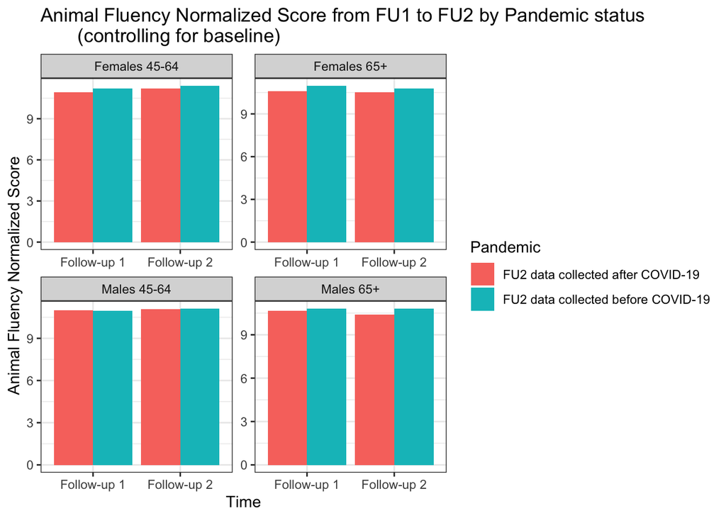

```r
Animals_lsmeans_adj11 <- summary(lsmeans(modelAnimals_adj11, ~timefactor|Pandemic|Age_sex))
Animals_lsmeans_adj11$Time<-NA
Animals_lsmeans_adj11$Time[Animals_lsmeans_adj11$timefactor==1]<-"Follow-up 1"
Animals_lsmeans_adj11$Time[Animals_lsmeans_adj11$timefactor==2]<-"Follow-up 2"
ggplot(Animals_lsmeans_adj11, aes(x = Time, y = lsmean, fill = Pandemic)) +
  geom_bar(stat="identity", position=position_dodge()) + facet_wrap(~Age_sex, scales = "free") +
  labs(x = "Time", y = "Animal Fluency Normalized Score", title = "Animal Fluency Normalized Score from FU1 to FU2 by Pandemic status
       (controlling for baseline)") +
  theme_bw()
```

### 6.4.4) Post-hoc comparisons

There was a significant difference between cohorts for males and females 65+. This post-hoc comparison determines if differences between cohorts at FU1 and FU2 for 65+ males and females are significant.

```r
lsmeans.Animals <- lsmeans(modelAnimals_adj11, ~Pandemic|timefactor|Age_sex)
contrast.Animals<-contrast(lsmeans.Animals,list(c2nd, c3rd),by=NULL)
contrast.Animals_95<-confint(contrast.Animals, parm, level = 0.95)
print(contrast.Animals)
```

```
##  contrast
##  structure(c(0, 0, 0, 0, 0, 0, 0, 0, 0, 0, 0, 0, 1, -1, -1, 1), dim = c(16L,
##  structure(c(0, 0, 0, 0, 1, -1, -1, 1, 0, 0, 0, 0, 0, 0, 0, 0), dim = c(16L,
##     estimate        SE       df t.ratio p.value
##   0.24297640 0.1345418 10195.99   1.806  0.0710
##  -0.06872897 0.1350530 10187.46  -0.509  0.6108
##
## Results are averaged over the levels of: Education, Ethnicity, IncomeLevel, SmokingStatus, Relationshipstatus, Livingstatus, Anxiety, MoodDisord
## Degrees-of-freedom method: kenward-roger
```

```r
print(contrast.Animals_95)
```

```
##  contrast
##  structure(c(0, 0, 0, 0, 0, 0, 0, 0, 0, 0, 0, 0, 1, -1, -1, 1), dim = c(16L,
##  structure(c(0, 0, 0, 0, 1, -1, -1, 1, 0, 0, 0, 0, 0, 0, 0, 0), dim = c(16L,
##     estimate        SE       df   lower.CL  upper.CL
##   0.24297640 0.1345418 10195.99 -0.0207520 0.5067048
##  -0.06872897 0.1350530 10187.46 -0.3334594 0.1960015
##
## Results are averaged over the levels of: Education, Ethnicity, IncomeLevel, SmokingStatus, Relationshipstatus, Livingstatus, Anxiety, MoodDisord
## Degrees-of-freedom method: kenward-roger
## Confidence level used: 0.95
```

Effect size from post-hoc

```r
df.contrast.animals<-as.data.frame(contrast.Animals)
n_males_65<-nrow(subset(Tracking.Adjusted_Final, Age_sex == "Males 65+" & Pandemic == "FU2 data collected after COVID-19"))
es_animals_males<-(df.contrast.animals[1,5]*2)/(sqrt(n_males_65 + n_males_65))

n_females_65<-nrow(subset(Tracking.Adjusted_Final, Age_sex == "Females 65+" & Pandemic == "FU2 data collected after COVID-19"))
es_animals_females<-(df.contrast.animals[2,5]*2)/(sqrt(n_females_65 + n_females_65))

print(es_animals_males)
```

```
## [1] 0.08897301
```

```r
print(es_animals_females)
```

```
## [1] -0.02502637
```

# 7) Physical Activity Results

## 7.1) Main effects model adjusted for baseline

### 7.1.1) Model

```r
modelPASE_2<- lmer(PASE_TOTAL ~ timefactor*Pandemic + Age + Sex + Education + Ethnicity + IncomeLevel + BMI + CESD.10baseline + SmokingStatus +
                         Relationshipstatus + Livingstatus + Anxiety + MoodDisord + Chronicconditions + PASE_TOTALbaseline +
                        (1|ID), data= Tracking.data_long_2)
summary(modelPASE_2)
```

```
## Linear mixed model fit by REML. t-tests use Satterthwaite's method [
## lmerModLmerTest]
## Formula: PASE_TOTAL ~ timefactor * Pandemic + Age + Sex + Education +
##     Ethnicity + IncomeLevel + BMI + CESD.10baseline + SmokingStatus +
##     Relationshipstatus + Livingstatus + Anxiety + MoodDisord +
##     Chronicconditions + PASE_TOTALbaseline + (1 | ID)
##    Data: Tracking.data_long_2
##
## REML criterion at convergence: 183275.2
##
## Scaled residuals:
##     Min      1Q  Median      3Q     Max
## -4.2555 -0.5466 -0.0281  0.5123  8.4498
##
## Random effects:
##  Groups   Name        Variance Std.Dev.
##  ID       (Intercept) 1016     31.87
##  Residual             2437     49.37
## Number of obs: 16761, groups:  ID, 8463
##
## Fixed effects:
##                                                          Estimate Std. Error
## (Intercept)                                             2.219e+02  7.166e+00
## timefactor2                                            -1.687e+01  1.132e+00
## PandemicFU2 data collected before COVID-19             -6.101e+00  1.309e+00
## Age                                                    -2.288e+00  6.799e-02
## SexM                                                    1.425e+01  1.160e+00
## EducationHigh School Diploma                           -2.617e+00  1.632e+00
## EducationLess than High School Diploma                 -4.094e+00  2.305e+00
## EducationSome College                                   2.128e+00  2.036e+00
## EthnicityWhite                                          3.439e+00  3.244e+00
## IncomeLevel>$150k                                       1.831e+01  3.034e+00
## IncomeLevel$100-150k                                    1.955e+01  2.426e+00
## IncomeLevel$20-50k                                      7.800e+00  1.614e+00
## IncomeLevel$50-100k                                     1.217e+01  1.740e+00
## BMI                                                    -4.280e-01  1.097e-01
## CESD.10baseline                                         4.701e-02  1.305e-01
## SmokingStatusFormer Smoker                              7.626e+00  2.223e+00
## SmokingStatusNever Smoked                               9.501e+00  2.313e+00
## SmokingStatusOccasional Smoker                          5.865e+00  4.389e+00
```

[output cut: 61 more lines]

```
## SmokingStatusOccasional Smoker                         0.181543
## RelationshipstatusMarried                              0.011989 *
## RelationshipstatusSeparated                            0.351807
## RelationshipstatusSingle                               0.000343 ***
## RelationshipstatusWidowed                              0.048363 *
## LivingstatusAssisted Living                            0.574722
## LivingstatusHouse                                      3.51e-12 ***
## LivingstatusOther                                      0.000458 ***
## AnxietyYes                                             0.065080 .
## MoodDisordYes                                          1.36e-05 ***
## Chronicconditions                                      3.53e-08 ***
## PASE_TOTALbaseline                                      < 2e-16 ***
## timefactor2:PandemicFU2 data collected before COVID-19 8.94e-14 ***
## ---
## Signif. codes:  0 '***' 0.001 '**' 0.01 '*' 0.05 '.' 0.1 ' ' 1
```

```
##
## Correlation matrix not shown by default, as p = 30 > 12.
## Use print(x, correlation=TRUE)  or
##     vcov(x)        if you need it
```

```r
anova(modelPASE_2)
```

```
## Type III Analysis of Variance Table with Satterthwaite's method
##                      Sum Sq Mean Sq NumDF  DenDF   F value    Pr(>F)
## timefactor           514724  514724     1 8405.3  211.2142 < 2.2e-16 ***
## Pandemic                303     303     1 8423.2    0.1243 0.7244118
## Age                 2760582 2760582     1 8441.4 1132.7885 < 2.2e-16 ***
## Sex                  367677  367677     1 8423.5  150.8742 < 2.2e-16 ***
## Education             17044    5681     3 8437.5    2.3313 0.0721741 .
## Ethnicity              2739    2739     1 8443.0    1.1241 0.2890678
## IncomeLevel          202160   50540     4 8431.1   20.7388 < 2.2e-16 ***
## BMI                   37134   37134     1 8424.7   15.2379 9.552e-05 ***
## CESD.10baseline         316     316     1 8439.4    0.1297 0.7187492
## SmokingStatus         41795   13932     3 8423.2    5.7168 0.0006633 ***
## Relationshipstatus    46556   11639     4 8428.0    4.7760 0.0007564 ***
## Livingstatus         135400   45133     3 8422.7   18.5203 5.692e-12 ***
## Anxiety                8295    8295     1 8445.4    3.4038 0.0650802 .
## MoodDisord            46178   46178     1 8429.8   18.9491 1.358e-05 ***
## Chronicconditions     74203   74203     1 8426.0   30.4488 3.530e-08 ***
## PASE_TOTALbaseline  5551634 5551634     1 8440.1 2278.0802 < 2.2e-16 ***
## timefactor:Pandemic  135920  135920     1 8405.4   55.7738 8.944e-14 ***
## ---
## Signif. codes:  0 '***' 0.001 '**' 0.01 '*' 0.05 '.' 0.1 ' ' 1
```

### 7.1.2) Estimated marginal means

```r
lsmeans(modelPASE_2, ~Pandemic|timefactor)
```

```
## timefactor = 1:
##  Pandemic                             lsmean       SE      df lower.CL upper.CL
##  FU2 data collected after COVID-19  153.7996 3.511413 8862.17 146.9164 160.6827
##  FU2 data collected before COVID-19 147.6986 3.510947 8779.83 140.8163 154.5809
##
## timefactor = 2:
##  Pandemic                             lsmean       SE      df lower.CL upper.CL
##  FU2 data collected after COVID-19  136.9284 3.511414 8862.20 130.0452 143.8116
##  FU2 data collected before COVID-19 142.2809 3.512128 8787.22 135.3964 149.1655
##
## Results are averaged over the levels of: Sex, Education, Ethnicity, IncomeLevel, SmokingStatus, Relationshipstatus, Livingstatus, Anxiety, MoodDisord
## Degrees-of-freedom method: kenward-roger
## Confidence level used: 0.95
```

```r
contrast(lsmeans(modelPASE_2, ~Pandemic|timefactor), "pairwise", adj="none")
```

```
## timefactor = 1:
##  contrast
##  (FU2 data collected after COVID-19) - (FU2 data collected before COVID-19)
##   estimate       SE       df t.ratio p.value
##   6.100967 1.308691 15242.39   4.662  <.0001
##
## timefactor = 2:
##  contrast
##  (FU2 data collected after COVID-19) - (FU2 data collected before COVID-19)
##   estimate       SE       df t.ratio p.value
##  -5.352526 1.310113 15253.88  -4.086  <.0001
##
## Results are averaged over the levels of: Sex, Education, Ethnicity, IncomeLevel, SmokingStatus, Relationshipstatus, Livingstatus, Anxiety, MoodDisord
## Degrees-of-freedom method: kenward-roger
```

```r
confint(contrast(lsmeans(modelPASE_2, ~Pandemic|timefactor), "pairwise", adj="none"), parm, level = 0.95)
```

```
## timefactor = 1:
##  contrast
##  (FU2 data collected after COVID-19) - (FU2 data collected before COVID-19)
##   estimate       SE       df  lower.CL  upper.CL
##   6.100967 1.308691 15242.39  3.535776  8.666158
##
## timefactor = 2:
##  contrast
##  (FU2 data collected after COVID-19) - (FU2 data collected before COVID-19)
##   estimate       SE       df  lower.CL  upper.CL
##  -5.352526 1.310113 15253.88 -7.920503 -2.784548
##
## Results are averaged over the levels of: Sex, Education, Ethnicity, IncomeLevel, SmokingStatus, Relationshipstatus, Livingstatus, Anxiety, MoodDisord
## Degrees-of-freedom method: kenward-roger
## Confidence level used: 0.95
```

### 7.1.3) Graph of estimated marginal means

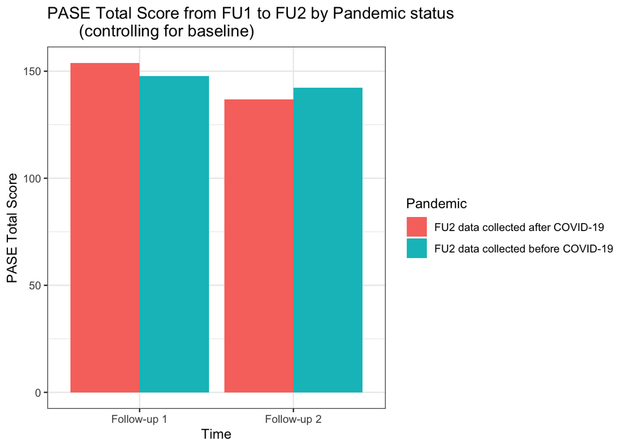

```r
PASE_lsmeans_2 <- summary(lsmeans(modelPASE_2, ~timefactor|Pandemic))
PASE_lsmeans_2$Time<-NA
PASE_lsmeans_2$Time[PASE_lsmeans_2$timefactor==1]<-"Follow-up 1"
PASE_lsmeans_2$Time[PASE_lsmeans_2$timefactor==2]<-"Follow-up 2"
ggplot(PASE_lsmeans_2, aes(x = Time, y = lsmean, fill = Pandemic)) +
  geom_bar(stat="identity", position=position_dodge()) +
  labs(x = "Time", y = "PASE Total Score", title = "PASE Total Score from FU1 to FU2 by Pandemic status
       (controlling for baseline)") +
  theme_bw()
```

### 7.1.4) Post-hoc comparisons

Test whether differences between cohorts at FU1 and FU2 are significant

```r
lsmeans.PASE <- lsmeans(modelPASE_2, ~Pandemic|timefactor)
contrast(lsmeans.PASE,list(c1st),by=NULL)
```

```
##  contrast                                     estimate       SE      df t.ratio
##  structure(c(-1, 1, 1, -1), dim = c(4L, 1L)) -11.45349 1.533639 8388.07  -7.468
##  p.value
##   <.0001
##
## Results are averaged over the levels of: Sex, Education, Ethnicity, IncomeLevel, SmokingStatus, Relationshipstatus, Livingstatus, Anxiety, MoodDisord
## Degrees-of-freedom method: kenward-roger
```

## 7.2) Age and Sex Interaction Model

### 7.2.1) Model

```r
modelPASE_4<- lmer(PASE_TOTAL ~ timefactor*Pandemic*Age_sex + Education + Ethnicity + IncomeLevel + BMI + CESD.10baseline + SmokingStatus +
                         Relationshipstatus + Livingstatus + Anxiety + MoodDisord + Chronicconditions + PASE_TOTALbaseline +
                        (1|ID), data= Tracking.data_long_2)
summary(modelPASE_4)
```

```
## Linear mixed model fit by REML. t-tests use Satterthwaite's method [
## lmerModLmerTest]
## Formula:
## PASE_TOTAL ~ timefactor * Pandemic * Age_sex + Education + Ethnicity +
##     IncomeLevel + BMI + CESD.10baseline + SmokingStatus + Relationshipstatus +
##     Livingstatus + Anxiety + MoodDisord + Chronicconditions +
##     PASE_TOTALbaseline + (1 | ID)
##    Data: Tracking.data_long_2
##
## REML criterion at convergence: 183747.3
##
## Scaled residuals:
##     Min      1Q  Median      3Q     Max
## -4.2584 -0.5478 -0.0318  0.5026  8.2959
##
## Random effects:
##  Groups   Name        Variance Std.Dev.
##  ID       (Intercept) 1163     34.10
##  Residual             2436     49.35
## Number of obs: 16761, groups:  ID, 8463
##
## Fixed effects:
##                                                                             Estimate
## (Intercept)                                                                8.661e+01
## timefactor2                                                               -1.884e+01
## PandemicFU2 data collected before COVID-19                                -9.908e+00
## Age_sexFemales 65+                                                        -3.403e+01
## Age_sexMales 45-64                                                         1.215e+01
## Age_sexMales 65+                                                          -2.577e+01
## EducationHigh School Diploma                                              -3.486e+00
## EducationLess than High School Diploma                                    -7.085e+00
## EducationSome College                                                     -7.104e-03
## EthnicityWhite                                                             8.466e-01
## IncomeLevel>$150k                                                          2.015e+01
## IncomeLevel$100-150k                                                       2.187e+01
## IncomeLevel$20-50k                                                         7.382e+00
## IncomeLevel$50-100k                                                        1.352e+01
## BMI                                                                       -2.147e-01
## CESD.10baseline                                                            2.343e-01
## SmokingStatusFormer Smoker                                                 4.874e+00
```

[output cut: 215 more lines]

```
## MoodDisordYes                                                             ***
## Chronicconditions                                                         ***
## PASE_TOTALbaseline                                                        ***
## timefactor2:PandemicFU2 data collected before COVID-19                    ***
## timefactor2:Age_sexFemales 65+
## timefactor2:Age_sexMales 45-64
## timefactor2:Age_sexMales 65+
## PandemicFU2 data collected before COVID-19:Age_sexFemales 65+             *
## PandemicFU2 data collected before COVID-19:Age_sexMales 45-64
## PandemicFU2 data collected before COVID-19:Age_sexMales 65+
## timefactor2:PandemicFU2 data collected before COVID-19:Age_sexFemales 65+
## timefactor2:PandemicFU2 data collected before COVID-19:Age_sexMales 45-64
## timefactor2:PandemicFU2 data collected before COVID-19:Age_sexMales 65+   .
## ---
## Signif. codes:  0 '***' 0.001 '**' 0.01 '*' 0.05 '.' 0.1 ' ' 1
```

```
##
## Correlation matrix not shown by default, as p = 40 > 12.
## Use print(x, correlation=TRUE)  or
##     vcov(x)        if you need it
```

```r
anova(modelPASE_4)
```

```
## Type III Analysis of Variance Table with Satterthwaite's method
##                              Sum Sq Mean Sq NumDF  DenDF   F value    Pr(>F)
## timefactor                   442646  442646     1 8402.9  181.7383 < 2.2e-16
## Pandemic                        201     201     1 8429.8    0.0826 0.7737564
## Age_sex                     1384531  461510     3 8423.1  189.4835 < 2.2e-16
## Education                     28802    9601     3 8434.2    3.9418 0.0080337
## Ethnicity                       156     156     1 8439.7    0.0640 0.8002934
## IncomeLevel                  249353   62338     4 8427.5   25.5944 < 2.2e-16
## BMI                            8813    8813     1 8419.9    3.6184 0.0571792
## CESD.10baseline                7392    7392     1 8435.1    3.0349 0.0815305
## SmokingStatus                 23822    7941     3 8419.8    3.2602 0.0205727
## Relationshipstatus            94904   23726     4 8423.9    9.7413 7.376e-08
## Livingstatus                 171433   57144     3 8419.7   23.4619 4.068e-15
## Anxiety                        1154    1154     1 8441.4    0.4739 0.4911980
## MoodDisord                    28226   28226     1 8426.5   11.5887 0.0006666
## Chronicconditions            197263  197263     1 8423.5   80.9908 < 2.2e-16
## PASE_TOTALbaseline          7007939 7007939     1 8433.3 2877.2689 < 2.2e-16
## timefactor:Pandemic          136800  136800     1 8403.0   56.1663 7.336e-14
## timefactor:Age_sex             7077    2359     3 8400.2    0.9685 0.4064712
## Pandemic:Age_sex              51900   17300     3 8429.6    7.1029 9.194e-05
## timefactor:Pandemic:Age_sex   19367    6456     3 8400.2    2.6505 0.0470920
##
## timefactor                  ***
## Pandemic
## Age_sex                     ***
## Education                   **
## Ethnicity
## IncomeLevel                 ***
## BMI                         .
## CESD.10baseline             .
## SmokingStatus               *
## Relationshipstatus          ***
## Livingstatus                ***
## Anxiety
## MoodDisord                  ***
## Chronicconditions           ***
## PASE_TOTALbaseline          ***
## timefactor:Pandemic         ***
## timefactor:Age_sex
## Pandemic:Age_sex            ***
## timefactor:Pandemic:Age_sex *
## ---
## Signif. codes:  0 '***' 0.001 '**' 0.01 '*' 0.05 '.' 0.1 ' ' 1
```

### 7.2.2) Estimated marginal means

Significant differences for females 45-64 and 65+ and significant differences males 65+

```r
lsmeans(modelPASE_4, ~Pandemic|timefactor|Age_sex)
```

```
## timefactor = 1, Age_sex = Females 45-64:
##  Pandemic                             lsmean       SE       df lower.CL
##  FU2 data collected after COVID-19  161.0236 3.956849  9694.02 153.2674
##  FU2 data collected before COVID-19 151.1153 3.816022  9269.85 143.6350
##  upper.CL
##  168.7799
##  158.5955
##
## timefactor = 2, Age_sex = Females 45-64:
##  Pandemic                             lsmean       SE       df lower.CL
##  FU2 data collected after COVID-19  142.1837 3.957538  9697.92 134.4261
##  FU2 data collected before COVID-19 143.9223 3.817220  9276.93 136.4397
##  upper.CL
##  149.9413
##  151.4049
##
## timefactor = 1, Age_sex = Females 65+:
##  Pandemic                             lsmean       SE       df lower.CL
##  FU2 data collected after COVID-19  126.9979 4.383494 10584.63 118.4054
##  FU2 data collected before COVID-19 125.8971 4.125053  9863.26 117.8112
##  upper.CL
##  135.5903
##  133.9831
##
## timefactor = 2, Age_sex = Females 65+:
##  Pandemic                             lsmean       SE       df lower.CL
##  FU2 data collected after COVID-19  113.3667 4.386095 10597.90 104.7691
##  FU2 data collected before COVID-19 120.7773 4.133577  9909.74 112.6746
##  upper.CL
##  121.9643
##  128.8799
##
## timefactor = 1, Age_sex = Males 45-64:
##  Pandemic                             lsmean       SE       df lower.CL
##  FU2 data collected after COVID-19  173.1740 3.808642  9369.91 165.7082
##  FU2 data collected before COVID-19 162.2827 3.937728  9675.41 154.5640
##  upper.CL
##  180.6397
##  170.0015
##
```

[output cut: 12 more lines]

```
##  upper.CL
##  143.7323
##  139.3084
##
## timefactor = 2, Age_sex = Males 65+:
##  Pandemic                             lsmean       SE       df lower.CL
##  FU2 data collected after COVID-19  113.7781 4.321121 10336.20 105.3079
##  FU2 data collected before COVID-19 130.3505 4.099185  9945.47 122.3152
##  upper.CL
##  122.2484
##  138.3857
##
## Results are averaged over the levels of: Education, Ethnicity, IncomeLevel, SmokingStatus, Relationshipstatus, Livingstatus, Anxiety, MoodDisord
## Degrees-of-freedom method: kenward-roger
## Confidence level used: 0.95
```

```r
contrast(lsmeans(modelPASE_4, ~Pandemic|timefactor|Age_sex), "pairwise", adj="none")
```

```
## timefactor = 1, Age_sex = Females 45-64:
##  contrast
##  (FU2 data collected after COVID-19) - (FU2 data collected before COVID-19)
##    estimate       SE       df t.ratio p.value
##    9.908324 2.330586 15131.45   4.251  <.0001
##
## timefactor = 2, Age_sex = Females 45-64:
##  contrast
##  (FU2 data collected after COVID-19) - (FU2 data collected before COVID-19)
##    estimate       SE       df t.ratio p.value
##   -1.738561 2.334011 15148.39  -0.745  0.4564
##
## timefactor = 1, Age_sex = Females 65+:
##  contrast
##  (FU2 data collected after COVID-19) - (FU2 data collected before COVID-19)
##    estimate       SE       df t.ratio p.value
##    1.100741 3.286172 15120.13   0.335  0.7377
##
## timefactor = 2, Age_sex = Females 65+:
##  contrast
##  (FU2 data collected after COVID-19) - (FU2 data collected before COVID-19)
##    estimate       SE       df t.ratio p.value
##   -7.410556 3.296664 15156.90  -2.248  0.0246
##
## timefactor = 1, Age_sex = Males 45-64:
##  contrast
##  (FU2 data collected after COVID-19) - (FU2 data collected before COVID-19)
##    estimate       SE       df t.ratio p.value
##   10.891247 2.359306 15148.60   4.616  <.0001
##
## timefactor = 2, Age_sex = Males 45-64:
##  contrast
##  (FU2 data collected after COVID-19) - (FU2 data collected before COVID-19)
##    estimate       SE       df t.ratio p.value
##    2.491337 2.360239 15153.11   1.056  0.2912
##
## timefactor = 1, Age_sex = Males 65+:
##  contrast
##  (FU2 data collected after COVID-19) - (FU2 data collected before COVID-19)
##    estimate       SE       df t.ratio p.value
##    3.978263 3.153565 15192.45   1.262  0.2071
##
## timefactor = 2, Age_sex = Males 65+:
##  contrast
##  (FU2 data collected after COVID-19) - (FU2 data collected before COVID-19)
##    estimate       SE       df t.ratio p.value
##  -16.572331 3.152200 15187.55  -5.257  <.0001
##
## Results are averaged over the levels of: Education, Ethnicity, IncomeLevel, SmokingStatus, Relationshipstatus, Livingstatus, Anxiety, MoodDisord
## Degrees-of-freedom method: kenward-roger
```

```r
confint(contrast(lsmeans(modelPASE_4, ~Pandemic|timefactor|Age_sex), "pairwise", adj="none"), parm, level = 0.95)
```

```
## timefactor = 1, Age_sex = Females 45-64:
##  contrast
##  (FU2 data collected after COVID-19) - (FU2 data collected before COVID-19)
##    estimate       SE       df   lower.CL   upper.CL
##    9.908324 2.330586 15131.45   5.340093  14.476555
##
## timefactor = 2, Age_sex = Females 45-64:
##  contrast
##  (FU2 data collected after COVID-19) - (FU2 data collected before COVID-19)
##    estimate       SE       df   lower.CL   upper.CL
##   -1.738561 2.334011 15148.39  -6.313503   2.836382
##
## timefactor = 1, Age_sex = Females 65+:
##  contrast
##  (FU2 data collected after COVID-19) - (FU2 data collected before COVID-19)
##    estimate       SE       df   lower.CL   upper.CL
##    1.100741 3.286172 15120.13  -5.340552   7.542035
##
## timefactor = 2, Age_sex = Females 65+:
##  contrast
##  (FU2 data collected after COVID-19) - (FU2 data collected before COVID-19)
##    estimate       SE       df   lower.CL   upper.CL
##   -7.410556 3.296664 15156.90 -13.872414  -0.948698
##
## timefactor = 1, Age_sex = Males 45-64:
##  contrast
##  (FU2 data collected after COVID-19) - (FU2 data collected before COVID-19)
##    estimate       SE       df   lower.CL   upper.CL
##   10.891247 2.359306 15148.60   6.266723  15.515771
##
## timefactor = 2, Age_sex = Males 45-64:
##  contrast
##  (FU2 data collected after COVID-19) - (FU2 data collected before COVID-19)
##    estimate       SE       df   lower.CL   upper.CL
##    2.491337 2.360239 15153.11  -2.135016   7.117689
##
## timefactor = 1, Age_sex = Males 65+:
##  contrast
##  (FU2 data collected after COVID-19) - (FU2 data collected before COVID-19)
##    estimate       SE       df   lower.CL   upper.CL
##    3.978263 3.153565 15192.45  -2.203103  10.159628
##
## timefactor = 2, Age_sex = Males 65+:
##  contrast
##  (FU2 data collected after COVID-19) - (FU2 data collected before COVID-19)
##    estimate       SE       df   lower.CL   upper.CL
##  -16.572331 3.152200 15187.55 -22.751022 -10.393640
##
## Results are averaged over the levels of: Education, Ethnicity, IncomeLevel, SmokingStatus, Relationshipstatus, Livingstatus, Anxiety, MoodDisord
## Degrees-of-freedom method: kenward-roger
## Confidence level used: 0.95
```